# R básico para ciencia de datos - Clase 6

Ph D. Stephanie Hereira-Pacheco

Universidad Autónoma de Tlaxcala

2026-05-23

## Gráficas en R — Clase 6

- Gráficas con R base
- Introducción a `ggplot2`
- Geometrías: puntos, boxplot, histograma, barras
- Colores y títulos
- Temas
- Facetas
- Guardar gráficas
- `ggpubr`: gráficas rápidas y bonitas
- Ejercicios

## R tiene dos sistemas de gráficas

**R base**

- Rápido para exploración
- Sin instalar paquetes
- Menos personalizable
- Funciones: `plot()`, `hist()`, `boxplot()`

**ggplot2**

- Más bonito y personalizable
- Gramática de capas
- Ideal para publicaciones
- Requiere `library(ggplot2)`

## R base: barplot

```r
data(iris)
counts <- table(iris$Species)
barplot(counts,
        main = "Número de flores por especie",
        xlab = "Especie", ylab = "Frecuencia",
        col  = c("orchid", "lightblue", "lightgreen"))
```

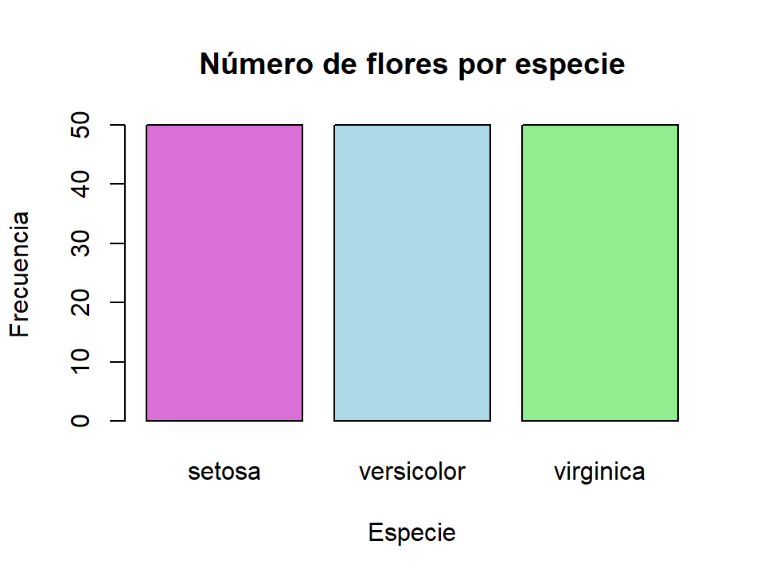

## R base: boxplot

```r
boxplot(Sepal.Length ~ Species, data = iris,
        main = "Longitud del sépalo por especie",
        xlab = "Especie", ylab = "Longitud (cm)",
        col  = c("orchid", "lightblue", "lightgreen"))
```

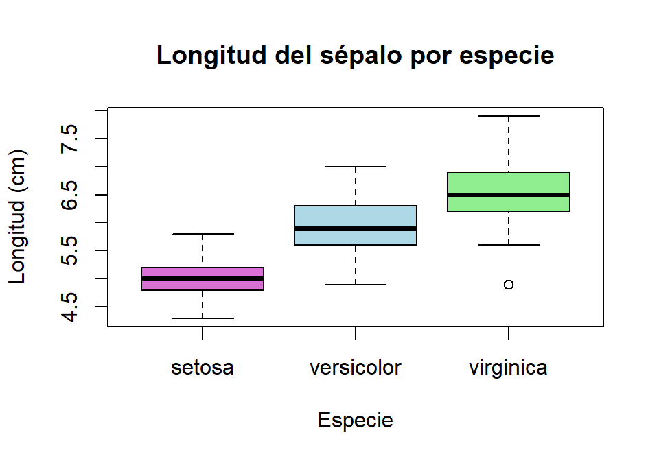

## R base: diagrama de dispersión

```r
plot(x = iris$Petal.Length, y = iris$Petal.Width,
     col  = iris$Species,
     xlab = "Largo pétalo", ylab = "Ancho pétalo",
     main = "Relación largo vs ancho del pétalo")
legend("topleft", legend = levels(iris$Species),
       fill = 1:3, title = "Especie")
```

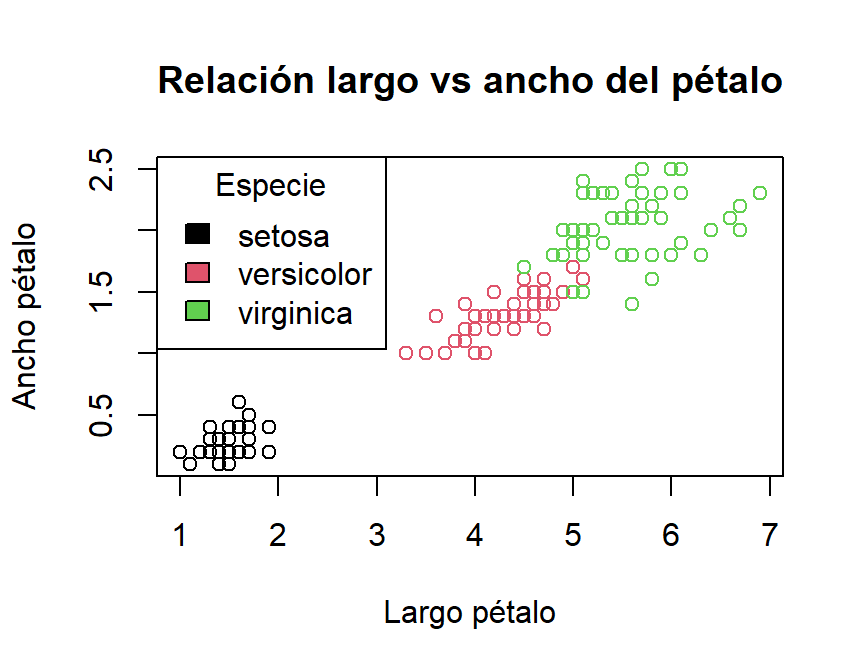

## R base: tipos de línea y punto (`type`, `lty`)

```r
df <- data.frame(x = 1:5, y = c(200, 400, 600, 700, 500))
par(mfrow = c(2, 3))
plot(df$x, df$y, type = "p", main = 'type = "p"  puntos')
plot(df$x, df$y, type = "l", main = 'type = "l"  líneas')
plot(df$x, df$y, type = "b", main = 'type = "b"  ambos')
plot(df$x, df$y, type = "l", lty = 1, main = "lty = 1  sólida")
plot(df$x, df$y, type = "l", lty = 2, main = "lty = 2  guiones")
plot(df$x, df$y, type = "l", lty = 3, main = "lty = 3  puntos")
```

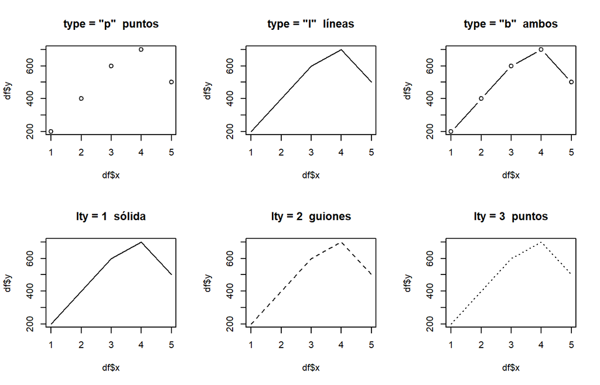

## Guardar una gráfica (R base)

```r
png(filename = "mi_grafica.png", width = 800, height = 600)

hist(iris$Sepal.Length, col = "steelblue",
     main = "Longitud del sépalo")

dev.off()
```

**Note**

El archivo se guarda en el directorio de trabajo. Se puede usar `jpeg()`, `pdf()` o `tiff()` de la misma manera.

## Introducción a `ggplot2`

`ggplot2` construye gráficas por **capas**:

1. **Datos** — el dataframe
2. **Estética (`aes`)** — qué variable va en x, en y, con qué color
3. **Geometría (`geom_`)** — el tipo de gráfica

```r
library(ggplot2)

ggplot(data = mis_datos, aes(x = variable_x, y = variable_y)) +
  geom_punto_o_caja_o_histograma()
```

Las capas se unen con **`+`** (no con el pipe).

## `ggplot2`: la pizarra en blanco

```r
library(ggplot2)
data("ToothGrowth")

ggplot(data = ToothGrowth, aes(x = dose, y = len))
```

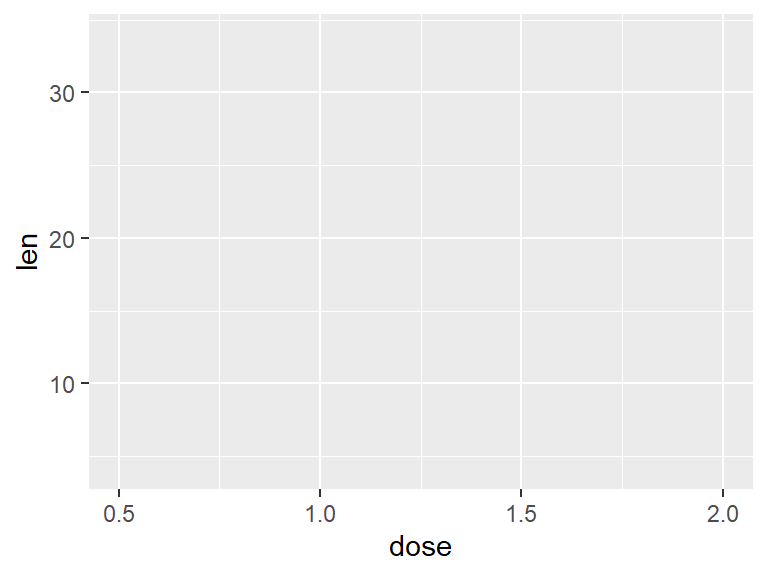

Sin `geom_`, ggplot solo muestra los ejes.

## `geom_point()`: diagrama de dispersión

```r
ggplot(ToothGrowth, aes(x = dose, y = len, color = supp)) +
  geom_point()
```

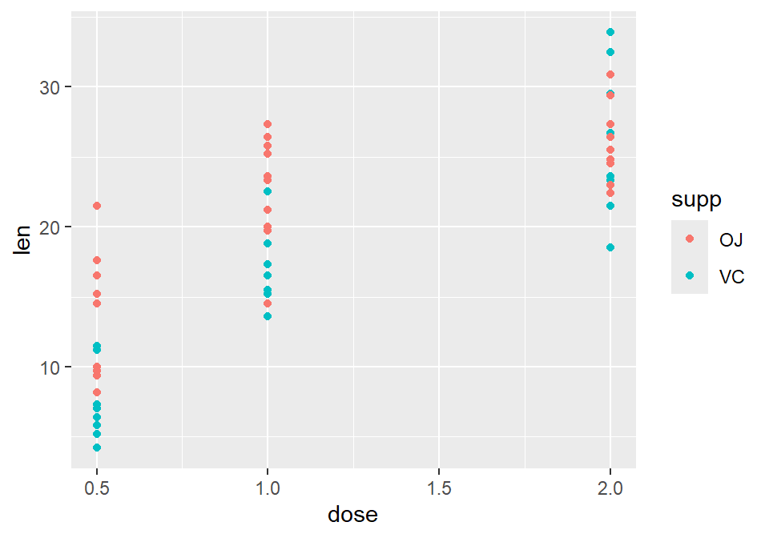

## `geom_boxplot()`: diagrama de cajas

Primero convertimos `dose` a factor para que sea una variable discreta:

```r
library(tidyverse)
ToothGrowth %>%
  mutate(dose = factor(dose)) %>%
  ggplot(aes(x = dose, y = len, fill = supp)) +
  geom_boxplot()
```

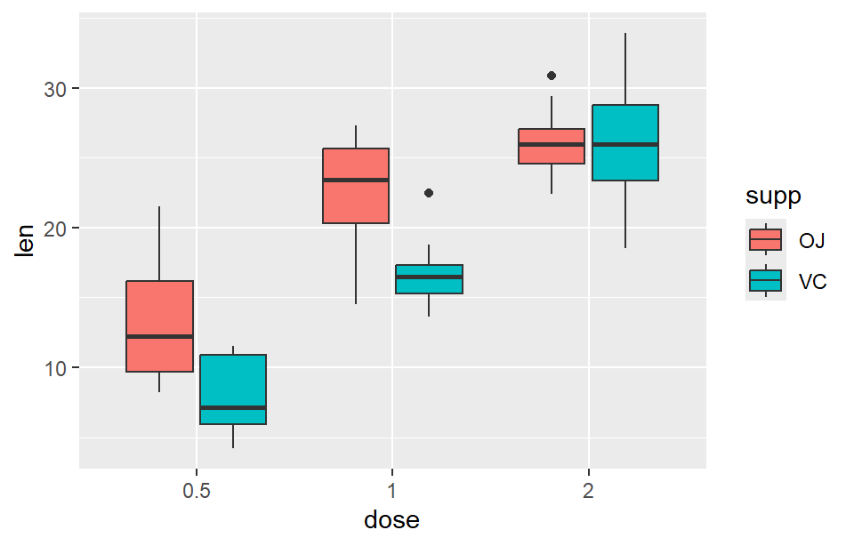

## `geom_histogram()`: histograma

```r
ggplot(iris, aes(x = Sepal.Length)) +
  geom_histogram(bins = 15, fill = "steelblue", color = "white")
```

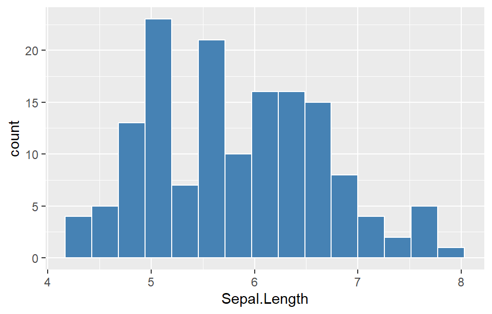

**Tip**

`bins` controla el número de barras. Prueba distintos valores para encontrar el más informativo.

## `geom_bar()`: gráfica de barras

Para barras de conteo por grupo:

```r
ggplot(iris, aes(x = Species, fill = Species)) +
  geom_bar()
```

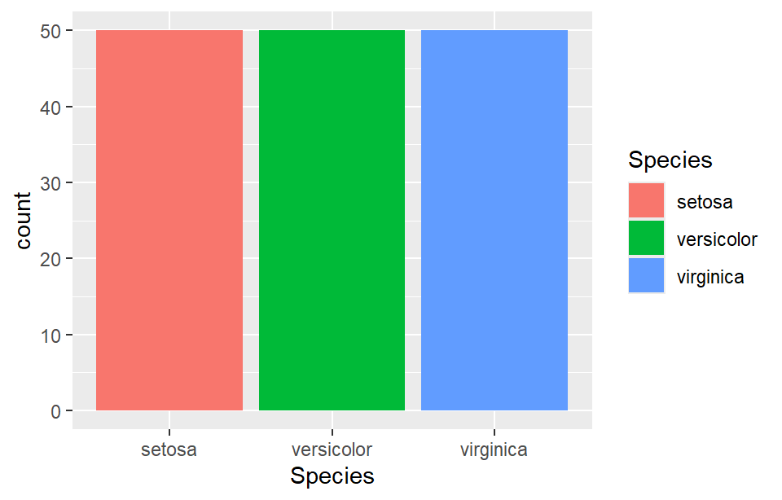

## Títulos y etiquetas: `labs()`

```r
ToothGrowth %>%
  mutate(dose = factor(dose)) %>%
  ggplot(aes(x = dose, y = len, fill = supp)) +
  geom_boxplot() +
  labs(title = "Longitud dental por dosis",
       x     = "Dosis (mg/día)",
       y     = "Longitud del diente",
       fill  = "Suplemento")
```

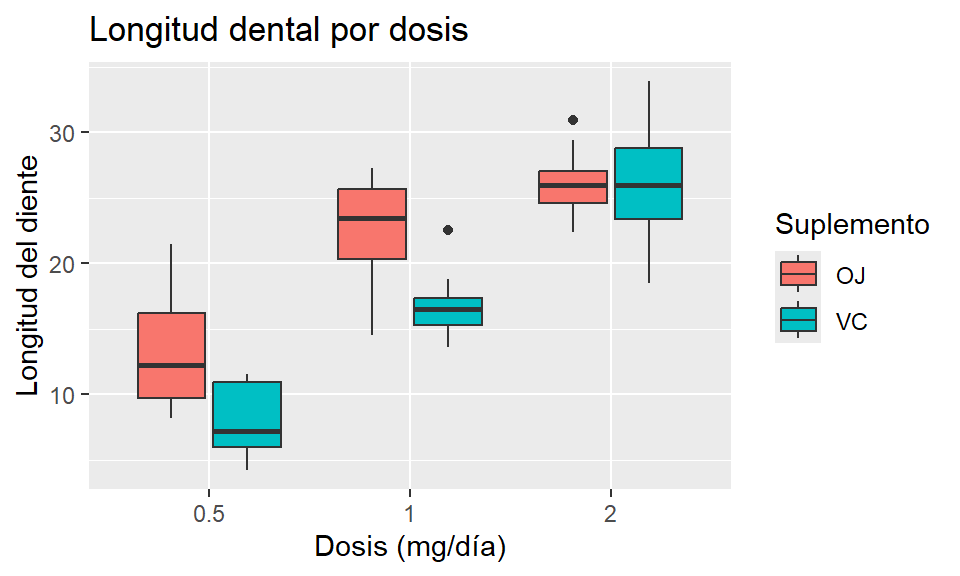

## Colores: `scale_fill_manual()`

Para definir los colores exactos que quieres:

```r
ToothGrowth %>%
  mutate(dose = factor(dose)) %>%
  ggplot(aes(x = dose, y = len, fill = supp)) +
  geom_boxplot() +
  scale_fill_manual(values = c("OJ" = "#E69F00", "VC" = "#56B4E9"))
```

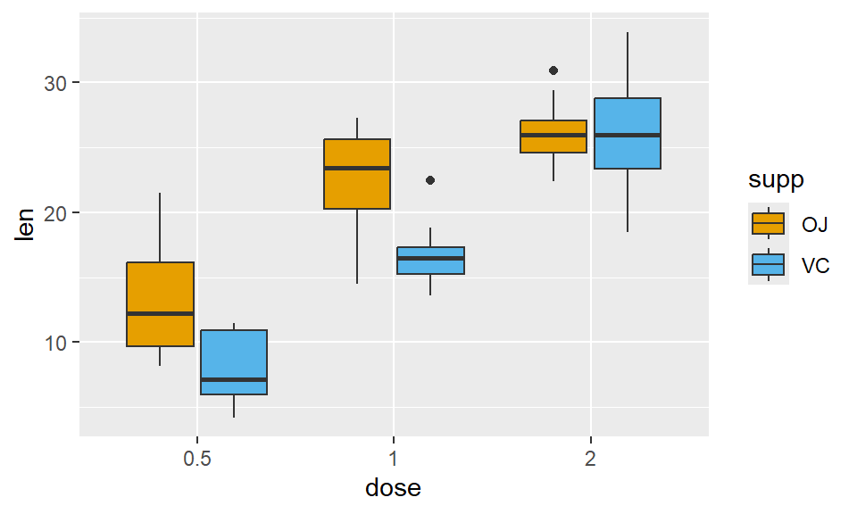

## Colores: paletas listas para usar

`scale_fill_brewer()` incluye paletas probadas. Ver todas: `RColorBrewer::display.brewer.all()`

```r
ToothGrowth %>%
  mutate(dose = factor(dose)) %>%
  ggplot(aes(x = dose, y = len, fill = dose)) +
  geom_boxplot() +
  scale_fill_brewer(palette = "Set2")
```

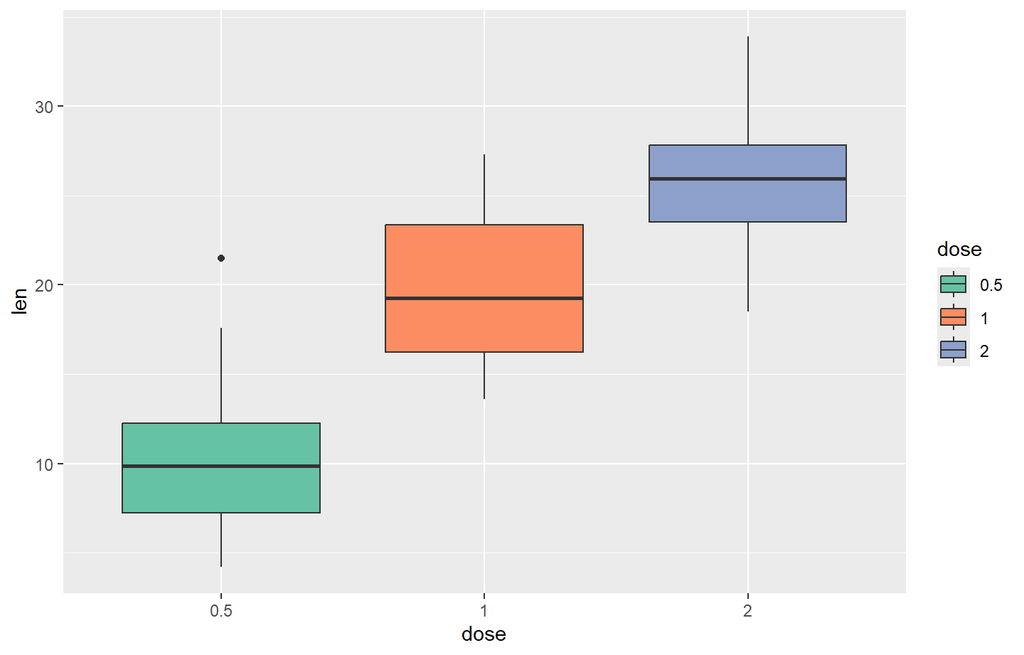

## Temas: cambiar el aspecto general

```r
ToothGrowth %>%
  mutate(dose = factor(dose)) %>%
  ggplot(aes(x = dose, y = len, fill = dose)) +
  geom_boxplot() +
  scale_fill_brewer(palette = "Set2") +
  labs(title = "Crecimiento dental por dosis") +
  theme_classic()
```

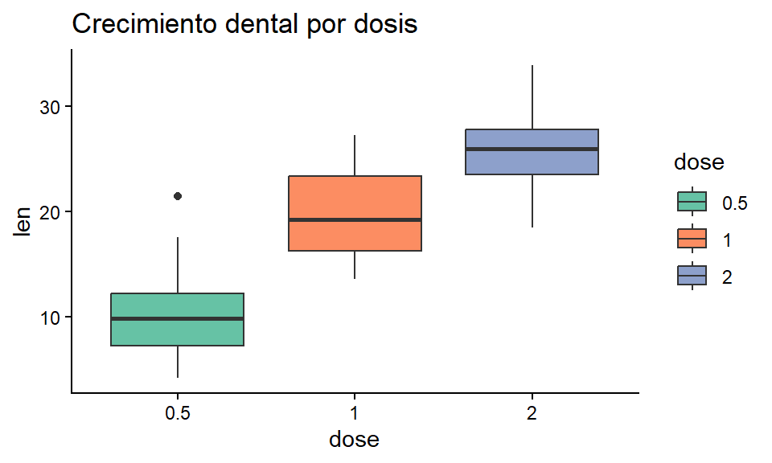

## Temas disponibles

| Tema | Estilo |
| --- | --- |
| `theme_grey()` | Default (fondo gris) |
| `theme_bw()` | Blanco y negro |
| `theme_classic()` | Limpio, sin cuadrícula |
| `theme_minimal()` | Muy limpio, minimalista |
| `theme_dark()` | Fondo oscuro |

**Tip**

En RStudio: escribe `theme_` y presiona **Tab** para ver todas las opciones.

## Facetas: `facet_wrap()`

Divide la gráfica en paneles según una variable categórica:

```r
ToothGrowth %>%
  mutate(dose = factor(dose)) %>%
  ggplot(aes(x = dose, y = len, fill = dose)) +
  geom_boxplot() +
  facet_wrap(~ supp) +
  theme_bw()
```

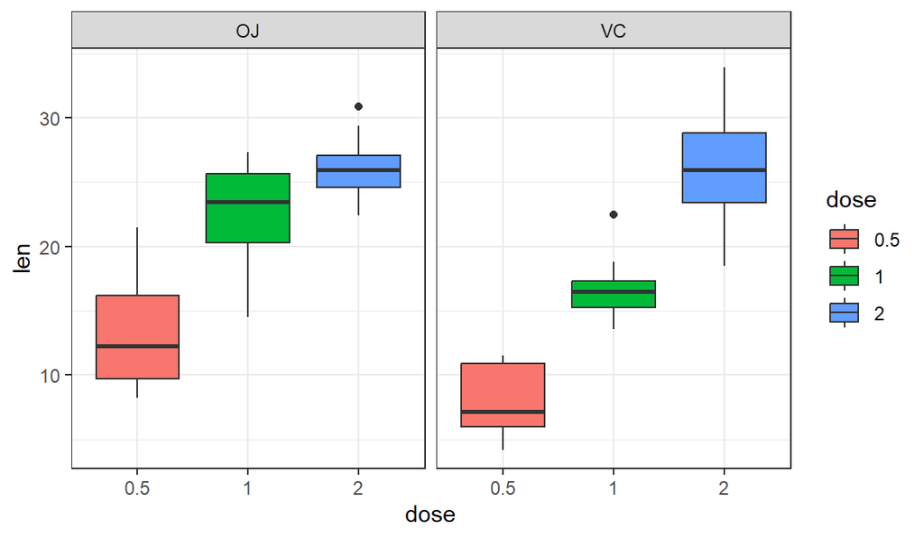

## Guardar con `ggsave()`

```r
mi_grafica <- ToothGrowth %>%
  mutate(dose = factor(dose)) %>%
  ggplot(aes(x = dose, y = len, fill = dose)) +
  geom_boxplot() +
  theme_classic()

ggsave(filename = "mi_grafica.png",
       plot     = mi_grafica,
       width    = 5,
       height   = 4,
       dpi      = 300)
```

**Note**

`dpi = 300` es la resolución estándar para publicaciones científicas.

## `ggpubr`: gráficas rápidas y listas

`ggpubr` ofrece funciones de una sola línea para gráficas publication-ready:

```r
library(ggpubr)

ggboxplot(ToothGrowth, x = "dose", y = "len",
          color = "dose", add = "jitter")
```

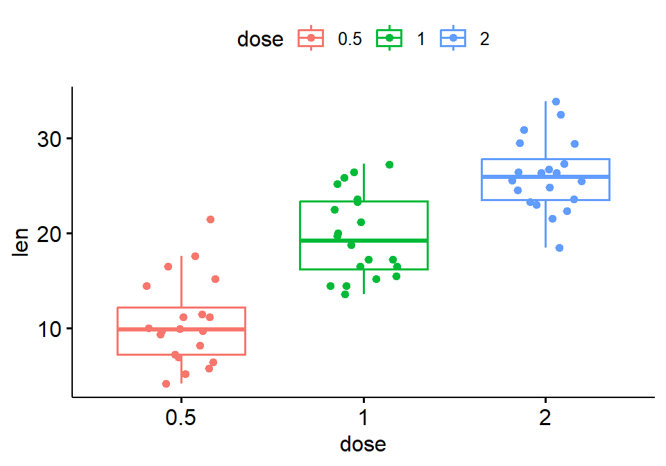

## `ggpubr`: barras con error

```r
ggbarplot(ToothGrowth, x = "dose", y = "len",
          fill = "dose", add = "mean_sd",
          palette = "Set2")
```

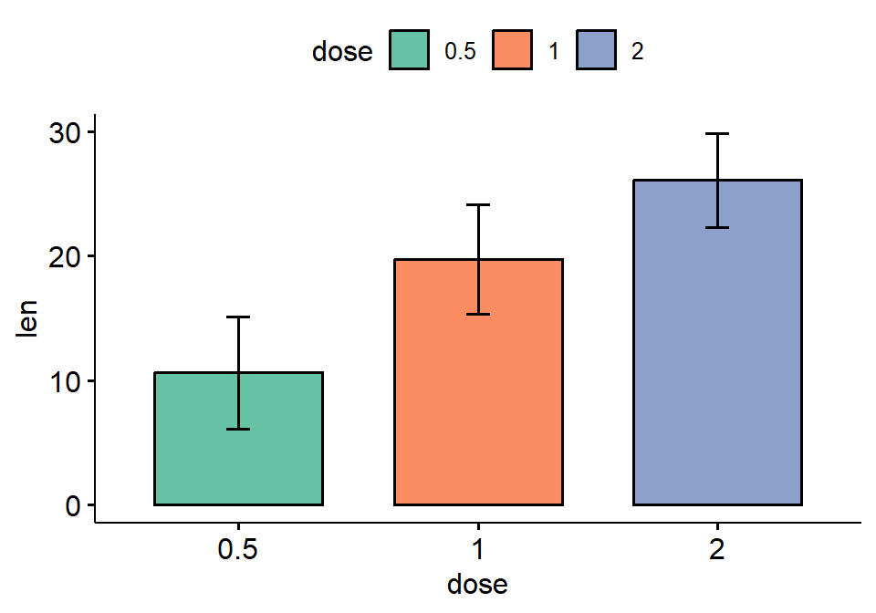

**Tip**

`add = "mean_sd"` agrega automáticamente las barras de error (media ± SD). También se puede usar `"mean_se"` para error estándar.

## `ggpubr`: multi-panel con `facet.by`

```r
ggboxplot(ToothGrowth, x = "dose", y = "len",
          color = "dose", facet.by = "supp",
          palette = "Set1")
```

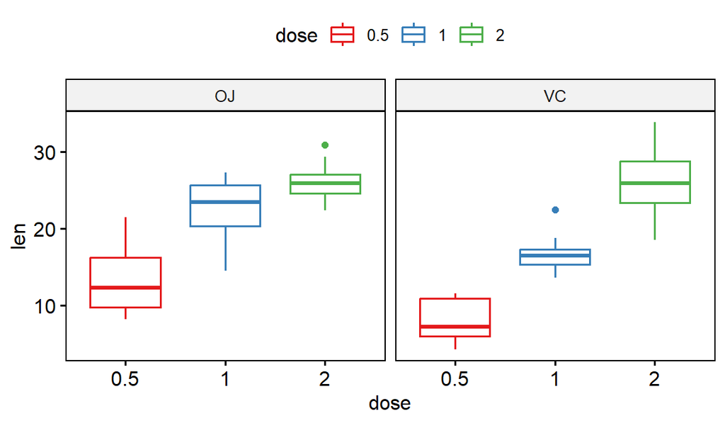

## Misceláneos: `ggcats`

`ggplot2` tiene una comunidad enorme que desarrolla extensiones creativas. **`ggcats`** reemplaza los puntos de una gráfica por imágenes de gatos 🐱

Se instala desde GitHub (no está en CRAN):

```r
# install.packages("remotes")   # solo si no lo tienes
remotes::install_github("R-CoderDotCom/ggcats@main")
```

**Note**

Repositorio y documentación: github.com/R-CoderDotCom/ggcats

## Misceláneos: `ggcats` — opciones disponibles

```r
library(ggcats)
grid <- expand.grid(1:5, 3:1)
df_cats <- data.frame(
  x     = grid[, 1],
  y     = grid[, 2],
  image = c("nyancat","bongo","colonel","grumpy","hipster",
            "lil_bub","maru","mouth","pop","pop_close",
            "pusheen","pusheen_pc","toast","venus","shironeko"))
ggplot(df_cats) +
  geom_cat(aes(x, y, cat = image), size = 5) +
  geom_text(aes(x, y - 0.45, label = image), size = 2.3) +
  xlim(c(0.25, 5.5)) + ylim(c(0.25, 3.5)) +
  theme_void()
```

[figure not shown]

## Misceláneos: `ggcats` en datos reales

```r
ToothGrowth$cats <- factor(ToothGrowth$dose,
  levels = c(0.5, 1, 2),
  labels = c("mouth", "grumpy", "pusheen_pc"))

ggplot(ToothGrowth, aes(x = dose, y = len)) +
  geom_cat(aes(cat = cats), size = 4) +
  xlim(c(0.25, 2.25)) +
  labs(x = "Dosis", y = "Longitud") +
  theme_classic()
```

[figure not shown]

## Ejercicios

**Note**

Usa el dataset `mtcars`. Cárgalo con `data(mtcars)`. Variables útiles: `mpg` (millas/galón), `wt` (peso), `hp` (caballos de fuerza), `cyl` (cilindros: 4, 6 u 8).

1. Convierte `cyl` a factor y haz un **barplot** del número de autos por cilindros con R base. Ponle título y colores.
2. Haz un **boxplot** de `mpg` por `cyl` con R base. Usa tres colores distintos.
3. Con `ggplot2`, haz un diagrama de dispersión de `wt` vs `mpg`, coloreando por `cyl` (como factor).

## Ejercicios (cont.)

4. Agrega títulos al gráfico anterior usando `labs()`.
5. Cambia el tema a `theme_classic()` y la paleta de colores con `scale_color_brewer()`.
6. Haz una gráfica de barras con `geom_bar()` de `cyl` (como factor), usando `fill = factor(cyl)`.
7. Haz un diagrama de dispersión de `hp` vs `mpg` con `geom_point()` y aplica `facet_wrap(~ cyl)` para ver cada grupo de cilindros en un panel separado.
8. Guarda la última gráfica como `ejercicio_mtcars.png` con `ggsave()` a 300 dpi.

## Referencias

- Wickham, H. (2016). *ggplot2: Elegant Graphics for Data Analysis*. ggplot2-book.org
- Kassambara, A. *ggpubr documentation*. rpkgs.datanovia.com/ggpubr
- Wickham, H. & Grolemund, G. (2017). *R for Data Science*. r4ds.had.co.nz
- CRAN — Comprehensive R Archive Network: cran.r-project.org

R básico para ciencia de datos · UAT 2026